# 张蕾

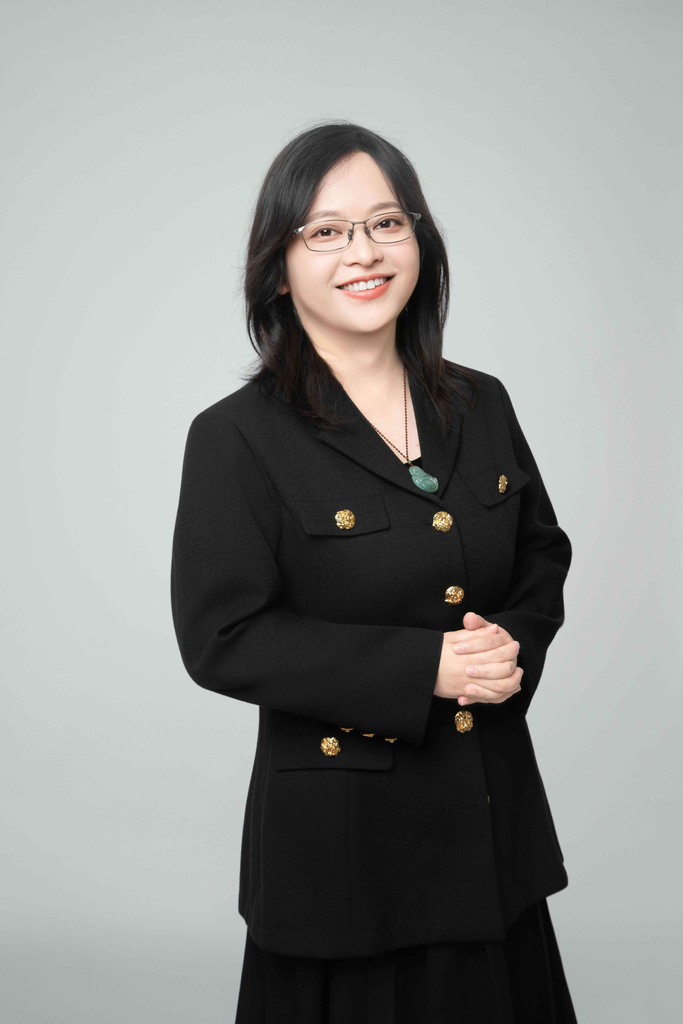

张 蕾 Lei Zhang

云南财经大学 财政与公共管理学院 副教授 · 硕士生导师  
Associate Professor, Master’s Supervisor, School of Finance and Public Administration, Yunnan University of Finance and Economics

博士研究生 / 博士学位 | Ph.D.

📧 380141793@qq.com

研究领域 Research Area：

复杂结构下的公共卫生数据质量管理 经管类实验课程建设 公共卫生与教育财政政策量化研究

中文

# 教育背景

云南大学 · 数学与应用数学专业 · 理学学士（专业排名第一；大一就读于软件学院信息安全专业）2006.09 – 2010.07

英国伦敦政治经济学院（LSE）· 统计学 · 理学硕士（优等学位 Distinction）2010.09 – 2011.12

英国布里斯托大学 · 社会科学与公共卫生中的高级计量方法 · 哲学博士2012.09 – 2016.09

# 工作经历

副教授（破格） · 云南财经大学财政与公共管理学院2026.10 – 至今

专任教师 · 云南财经大学财政与公共管理学院2023.10 – 2026.09

博士后研究员 · 英国布里斯托大学医学院（2018.11 加入 Jonathan Sterne 教授团队）2018.02 – 2022.09

博士后研究员 · 英国布里斯托大学教育学院（Sally Thomas 与 Harvey Goldstein 教授团队）2016.10 – 2018.01

# 研究成果

## 主持科研项目

时空嵌套结构下西部高危地区HIV监测数据缺失生成风险测度与预警机制研究2027.01–2029.12

编号72604377资助机构国家自然科学基金青年项目C类经费30万状态在研

高维时空嵌套结构下西部地区艾滋病监测数据缺失值多重插补效率优化研究2025.12–2028.09

编号25YJCZH361资助机构教育部人文社科基金青年项目经费8万状态在研

高维时空嵌套结构下云南省HIV监测数据缺失模式识别与插补策略适配性研究2026.05–2029.06

编号202601CI070081资助机构云南省科技厅基础研究青年项目经费5万状态在研

高维嵌套数据结构中的缺失数据插补方法比较研究2024.11–2027.03

编号2025J0583资助机构云南省教育厅科学研究基金项目经费1万状态在研

不同样本容量下高维嵌套数据统计模型内生性问题研究2024.10–2027.01

编号2024D34资助机构云南财经大学人才引进项目经费8万状态在研

## 参与科研项目

财税政策赋能西部先进制造业与生产性服务业融合发展研究2025.05–2028.12

资助机构国家社会科学基金西部项目经费20万状态角色在研·参与

复杂网络视角下云南税收营商环境与创新要素配置效率提升研究2026.05–2029.06

资助机构云南省科技厅基础研究面上项目经费10万状态角色在研·参与

Collaborative Research in HIV/AIDS, Alcohol, and Related Comorbidities (COMpAAAS) Tripartite: ART-CC, KP, and VA2017.09–2024.07

资助机构美国医学部经费1537万状态角色已结题·参与

Developing Research Impact of ITDEQC and IEEQC projects2016.09–2019.04

资助机构英国社科基金（ESRC）经费—状态角色已结题·参与

Widening Participation Research cluster, Exploring value added measures for UoB undergraduate students2014.04–2018.01

资助机构英国布里斯托大学经费—状态角色已结题·参与

Evaluation of Research Learning Communities2014.05–2016.05

资助机构Educational Endowment Foundations经费—状态角色已结题·参与

西部地区“省直管县”财政体制改革风险及风险防范研究2014.01–2016.12

资助机构国家自然科学基金地区项目经费23万状态角色已结题·参与

云南省职业教育发展与公共政策扶持的理论与实践研究2011.01–2020.10

资助机构云南省财政厅经费70万状态角色已结题·参与·课题组副组长

西部农村义务教育投入保障制度研究2006.01–2009.12

资助机构国家自然科学基金地区项目经费17万状态角色已结题·参与

促进我国经济结构调整的财税政策研究——基于西部地区视角2010.01–2010.12

资助机构财政部协作课题经费2万状态角色已结题·参与

促进云南省经济结构调整的财税政策研究2010.01–2010.12

资助机构财政部协作课题经费2万状态角色已结题·参与

## 教学改革项目

多平台融合路径下的双语财政学实验教学改革研究2025.04–2027.09

资助机构云南财经大学本科教育教学改革项目经费1万状态在研角色主持

## 代表性论文

Associations of modern initial antiretroviral drug regimens with all-cause mortality in adults with HIV in Europe and North America: a cohort study2022.07

期刊Lancet HIV（中科院1区TOP，IF=16.5）署名二作

Life expectancy of people with HIV on long-term antiretroviral therapy in Europe and North America: a cohort study2022.03

期刊Lancet Healthy Longevity（中科院1区，IF=13）署名二作

Care interruptions and mortality among adults in Europe and North America2024.08

期刊AIDS（中科院2区，IF=3.8）署名二作

对依法理财的理性思考2015.06

期刊《财政研究》（A类CSSCI）署名三作

西部“省直管县”财政体制改革风险因素分析：过度依赖财政型发展模式2013.06

期刊《财政研究》（CSSCI）署名三作

我国土地财政生成机理分析及解决思路2010.12

期刊《财政研究》（CSSCI）署名四作

西部地区“省直管县”财政体制改革管理风险的生成、传导与防范——以云南为例2013.12

期刊《地方财政研究》（CSSCI扩，北核）署名二作

“十二五”期间推进我国财政支出绩效管理的难点与解决思路2011.09

期刊《经济问题探索》（CSSCI）署名五作

A Multilevel Modeling Analysis of Household Digital Technology and Senior High School Students’ English Achievement in Western China2025.05

期刊IEEE（EI核心）署名独作

Estimating school and teacher effects on students’ academic performance using multilevel models with three or more levels2025.01

期刊Discover Education（Scopus核心）署名独作

## 学术著作

《多层次模型中的高维嵌套数据分析：从内生性处理到缺失值校正》2026.01

出版社经济科学出版社署名独著

《云南省职业教育发展与公共政策扶持的理论与实践研究》2020.10

出版社经济科学出版社署名参著（3/11）

《西部地区“省直管县”财政体制改革风险及风险防范研究》2014.10

出版社经济科学出版社署名参著（3/11）

# 主讲课程

- **本科课程：** 应用计量经济学（双语）、综合性及设计性实验 I、综合性及设计性实验 II、统计学（辅修）、计量经济学（挂牌）、统计学（挂牌）

# 获奖情况

### 教学获奖

- 2025年 全国高校经管类实验教学案例大赛（教师类）西南赛区三等奖（独立，省级）
- 2026年 教学基本功大赛二等奖（院级，云南财经大学财政与公共管理学院）

### 科研获奖

- 2012年 财政部科研成果二等奖（排名第4，省部级，财政部）
- 2010年 中国财政学会科研成果一等奖（排名第11，省部级，中国财政学会）

### 其他获奖

- 2026年 科学研究奖（项目类）（独立，校级，云南财经大学）
- 2026年 优秀班主任（独立，院级，云南财经大学财政与公共管理学院）

### 指导学生获奖

- 2026年 全国高校经济决策虚仿大赛国赛二等奖一项，区域赛三等奖四项
- 2026年 “外研社·国才杯”“理解当代中国”全国大学生外语能力大赛英语组“四新”专项赛校赛一等奖一项（晋级省赛）
- 2025年 全国高校经济决策虚仿大赛区域赛优秀奖三项

# 社会兼职

《经济学动态》、*School Effectiveness and School Improvement* 等 CSSCI/SSCI/SCI 期刊匿名评审专家

English

# Education

Yunnan University · Mathematics and Applied Mathematics · B.Sc. (Ranked 1st in Major; first-year study in Information Security, School of Software)Sep 2006 – Jul 2010

London School of Economics and Political Science (LSE), UK · Statistics · M.Sc. (with Distinction)Sep 2010 – Dec 2011

University of Bristol, UK · Advanced Quantitative Methods in Social Science and Public Health · Ph.D.Sep 2012 – Sep 2016

# Work Experience

Associate Professor (Accelerated Promotion) · School of Finance and Public Administration, Yunnan University of Finance and EconomicsOct 2026 – Present

Lecturer · School of Finance and Public Administration, Yunnan University of Finance and EconomicsOct 2023 – Sep 2026

Postdoctoral Research Associate · Medical School, University of Bristol, UK (joined Prof. Jonathan Sterne’s team in Nov 2018)Feb 2018 – Sep 2022

Postdoctoral Research Associate · School of Education, University of Bristol, UK (Prof. Sally Thomas and Prof. Harvey Goldstein’s team)Oct 2016 – Jan 2018

# Research Output

## Principal Investigator (PI) Projects

Risk Measurement and Early-Warning Mechanisms for Missing Data Generation in HIV Surveillance in High-Risk Areas of Western China under Spatiotemporal Nested StructuresJan 2027–Dec 2029

Grant No.72604377Funding BodyNSFC Young Scientists Fund (Category C)FundingCNY 300,000StatusOngoing

Optimizing Multiple Imputation Efficiency for Missing Values in HIV/AIDS Surveillance Data in Western China under High-dimensional Spatiotemporal Nested StructuresDec 2025–Sep 2028

Grant No.25YJCZH361Funding BodyMOE Youth Fund for Humanities and Social SciencesFundingCNY 80,000StatusOngoing

Missing Data Pattern Recognition and Imputation Strategy Adaptation for Yunnan HIV Surveillance Data under High-dimensional Spatiotemporal Nested StructuresMay 2026–Jun 2029

Grant No.202601CI070081Funding BodyYunnan Dept. of Science & Technology, Basic Research Youth ProjectFundingCNY 50,000StatusOngoing

A Comparative Study of Missing Data Imputation Methods for High-dimensional Nested Data StructuresNov 2024–Mar 2027

Grant No.2025J0583Funding BodyYunnan Dept. of Education Research FundFundingCNY 10,000StatusOngoing

Endogeneity in Statistical Models for High-dimensional Nested Data under Varying Sample SizesOct 2024–Jan 2027

Grant No.2024D34Funding BodyYUFE Talent Introduction ProgramFundingCNY 80,000StatusOngoing

## Co-investigator / Participant Projects

Empowering the Integrated Development of Advanced Manufacturing and Producer Services in Western China through Fiscal PolicyMay 2025–Dec 2028

Funding BodyNational Social Science Fund of China, Western Region ProjectFundingCNY 200,000Status / RoleOngoing · Participant

Improving the Allocation Efficiency of Innovation Factors and the Tax-related Business Environment in Yunnan from a Complex Network PerspectiveMay 2026–Jun 2029

Funding BodyYunnan Dept. of Science & Technology, General ProgramFundingCNY 100,000Status / RoleOngoing · Participant

Collaborative Research in HIV/AIDS, Alcohol, and Related Comorbidities (COMpAAAS) Tripartite: ART-CC, KP, and VASep 2017–Jul 2024

Funding BodyUS National Institutes of Health (NIH)FundingUSD 15.37 millionStatus / RoleCompleted · Participant

Developing Research Impact of ITDEQC and IEEQC projectsSep 2016–Apr 2019

Funding BodyUK Economic and Social Research Council (ESRC)Funding—Status / RoleCompleted · Participant

Widening Participation Research cluster, Exploring value added measures for UoB undergraduate studentsApr 2014–Jan 2018

Funding BodyUniversity of Bristol, UKFunding—Status / RoleCompleted · Participant

Evaluation of Research Learning CommunitiesMay 2014–May 2016

Funding BodyEducational Endowment Foundation (EEF)Funding—Status / RoleCompleted · Participant

Fiscal System Reform Risks and Risk Prevention under the “Province-Directly-Governing-County” Model in Western ChinaJan 2014–Dec 2016

Funding BodyNational Natural Science Foundation of China, Regional ProjectFundingCNY 230,000Status / RoleCompleted · Participant

Theory and Practice of Vocational Education Development and Public Policy Support in Yunnan ProvinceJan 2011–Oct 2020

Funding BodyYunnan Provincial Department of FinanceFundingCNY 700,000Status / RoleCompleted · Participant, Deputy Team Lead

A Study on the Input Guarantee System for Compulsory Education in Rural Western ChinaJan 2006–Dec 2009

Funding BodyNational Natural Science Foundation of China, Regional ProjectFundingCNY 170,000Status / RoleCompleted · Participant

Fiscal and Tax Policies for Promoting China’s Economic Structural Adjustment: A Western Region PerspectiveJan 2010–Dec 2010

Funding BodyMinistry of Finance Collaborative ProjectFundingCNY 20,000Status / RoleCompleted · Participant

Fiscal and Tax Policies for Promoting Economic Structural Adjustment in Yunnan ProvinceJan 2010–Dec 2010

Funding BodyMinistry of Finance Collaborative ProjectFundingCNY 20,000Status / RoleCompleted · Participant

## Teaching Reform Project

Bilingual Fiscal Studies Experimental Teaching Reform via Multi-platform IntegrationApr 2025–Sep 2027

Funding BodyUndergraduate Teaching Reform Project, Yunnan University of Finance and EconomicsFundingCNY 10,000StatusOngoingRolePI

## Selected Publications

Associations of modern initial antiretroviral drug regimens with all-cause mortality in adults with HIV in Europe and North America: a cohort studyJul 2022

Journal / VenueLancet HIV (CAS Zone 1 Top, IF=16.5)Authorship2nd Author

Life expectancy of people with HIV on long-term antiretroviral therapy in Europe and North America: a cohort studyMar 2022

Journal / VenueLancet Healthy Longevity (CAS Zone 1, IF=13)Authorship2nd Author

Care interruptions and mortality among adults in Europe and North AmericaAug 2024

Journal / VenueAIDS (CAS Zone 2, IF=3.8)Authorship2nd Author

Rational Reflections on Managing Public Finances in Accordance with the LawJun 2015

Journal / VenuePublic Finance Research (CSSCI Class A)Authorship3rd Author

Analysis of Risk Factors in the “Province-Directly-Governing-County” Fiscal Reform in Western China: An “Over-reliance on Fiscal Transfers” Development ModelJun 2013

Journal / VenuePublic Finance Research (CSSCI)Authorship3rd Author

Analysis of the Formation Mechanism of Land-based Finance in China and SolutionsDec 2010

Journal / VenuePublic Finance Research (CSSCI)Authorship4th Author

Generation, Transmission, and Prevention of Management Risks in the “Province-Directly-Governing-County” Fiscal Reform in Western China: The Case of YunnanDec 2013

Journal / VenueLocal Fiscal Research (CSSCI Extended, PKU Core)Authorship2nd Author

Difficulties and Solutions in Advancing Fiscal Expenditure Performance Management in China during the 12th Five-Year Plan PeriodSep 2011

Journal / VenueEconomic Problems Exploration (CSSCI)Authorship5th Author

A Multilevel Modeling Analysis of Household Digital Technology and Senior High School Students’ English Achievement in Western ChinaMay 2025

Journal / VenueIEEE (EI Core)AuthorshipSole Author

Estimating school and teacher effects on students’ academic performance using multilevel models with three or more levelsJan 2025

Journal / VenueDiscover Education (Scopus Core)AuthorshipSole Author

## Books & Monographs

High-dimensional Nested Data Analysis in Multilevel Models: From Endogeneity Treatment to Missing Data CorrectionJan 2026

PublisherEconomic Science PressAuthorshipSole Author

Theory and Practice of Vocational Education Development and Public Policy Support in Yunnan ProvinceOct 2020

PublisherEconomic Science PressAuthorshipContributing Author (3/11)

Fiscal System Reform Risks and Risk Prevention under the “Province-Directly-Governing-County” Model in Western ChinaOct 2014

PublisherEconomic Science PressAuthorshipContributing Author (3/11)

# Courses Taught

- **Undergraduate:** Applied Econometrics (Bilingual), Comprehensive & Design-based Experiment I, Comprehensive & Design-based Experiment II, Statistics (Minor Program), Econometrics (Cross-listed), Statistics (Cross-listed)

# Awards

### Teaching Awards

- 2025 — Third Prize (Southwest Region), National University Experimental Teaching Case Competition for Economics & Management (Faculty Category), Sole Awardee, Provincial level
- 2026 — Second Prize, Teaching Fundamentals Competition, School level (School of Finance and Public Administration, YUFE)

### Research Awards

- 2012 — Second Prize, Research Achievement Award, Ministry of Finance (Ranked 4th, Provincial/Ministerial level)
- 2010 — First Prize, Research Achievement Award, China Institute of Public Finance (Ranked 11th, Provincial/Ministerial level)

### Other Awards

- 2026 — YUFE Scientific Research Award (Project Category), Sole Awardee, University level
- 2026 — Outstanding Class Advisor, Sole Awardee, School level (School of Finance and Public Administration, YUFE)

### Student Mentoring Awards

- 2026 — National University Economic Decision-Making Simulation Competition, National Finals: 1 Second Prize，Regional Round: 4 Third Prizes
- 2026 — FLTRP Cup “Understanding Contemporary China” National College Students’ Foreign Language Competition, English Category, “Four New Disciplines” Special Track, School Round: 1 First Prize (advanced to the Provincial Round)
- 2025 — National University Economic Decision-Making Simulation Competition, Regional Round: 3 Merit Awards

# Academic Service

Anonymous peer reviewer for journals including *Economic Perspectives* (经济学动态) and *School Effectiveness and School Improvement*, among other CSSCI/SSCI/SCI-indexed journals.

张蕾 学术主页 · 更新于 2026 年 | Lei Zhang’s Academic Homepage · Updated 2026